# Индивидуальный проект

Первый этап

Нечаева К.А.

Российский университет дружбы народов, Москва, Россия

02 марта 2024

# Информация

## Докладчик

- Нечаева Кира Андреевна
- Cтудентка
- Российский университет дружбы народов
- 1132236031@pfur.ru

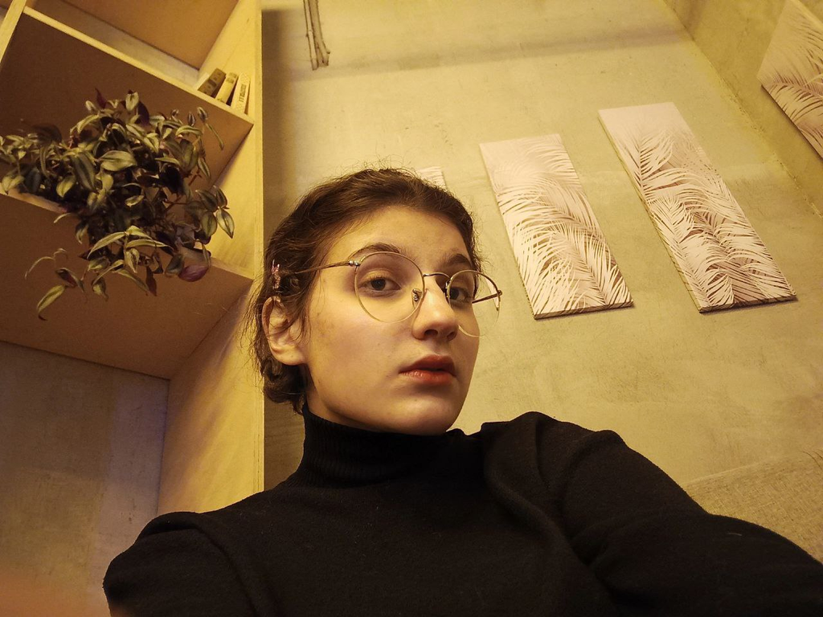

# Вводная часть

## Актуальность

- Hugo является самой удобной платформой для создания сайтов.
- Важно уметь создать свой сайт, чтобы сообщить о своих достижениях.
- Необходимо уметь реализовывать и визуализировать свои задумки для зрителей.

## Объект и предмет исследования

- Hugo
- Работа на Github

## Цели и задачи

- Создание основных элементов для сайта на hugo
- Первоначальная настройка сайта

## Материалы и методы

- Система Git
- Консоль (терминал) Linux

# Ход работы по проекту

## Установка необходимого ПО

- Для начала я устанавливаю go, так как на нем написан hugo, и, соответственно, без go ничего работать не будет.
- После этого я скачала с официального репозитория hugo архив с последней версией Hugo Extended и затем в терминале разархивировала его и удалила лишние файлы.

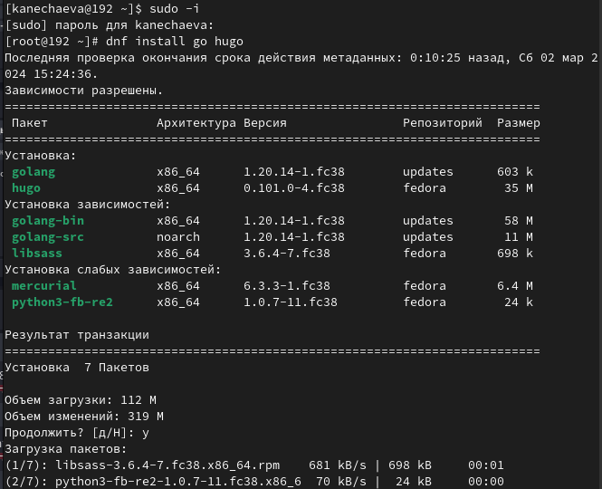

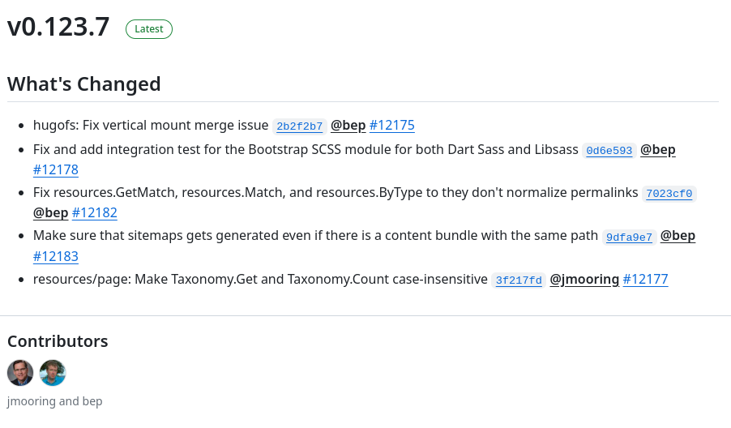

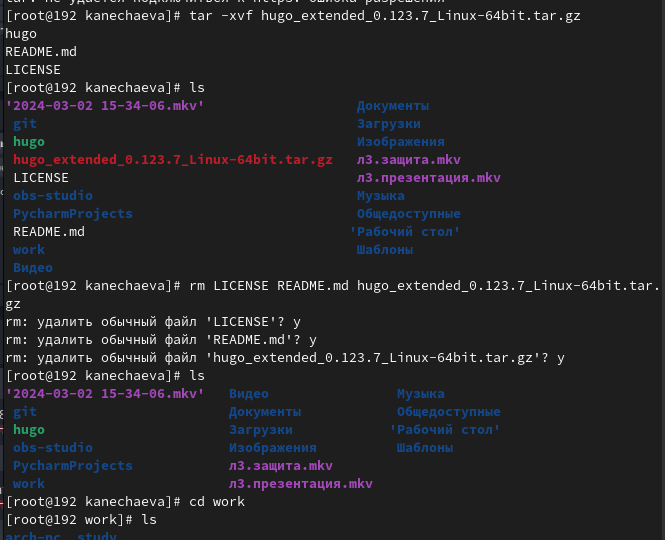

## Структура сайта

- Теперь я захожу на репозиторий hugo, откуда я возьму шаблон для своего репозитория сайта.
- Там же я создаю свой репозиторий, нажав на кнопку “Use this template”.
- Теперь я клонирую репозиторий к себе на компьютер.

[figure not shown]

[figure not shown]

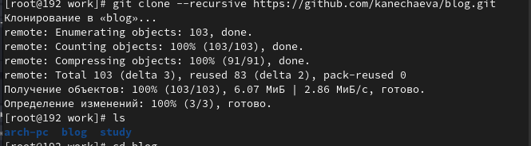

## Настройка сайта

[figure not shown]

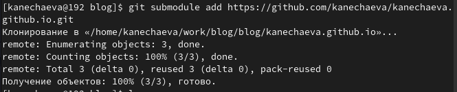

## Публикация сайта

- После этого с помощью команды hugo я фиксирую изменения на сайте.
- И наконец отправляю все изменения на Github.

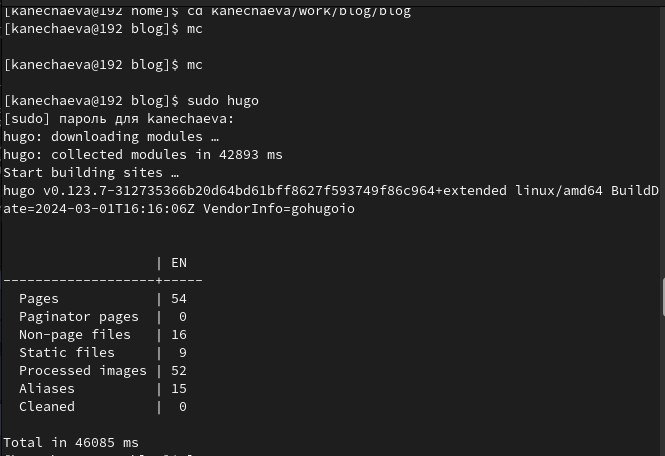

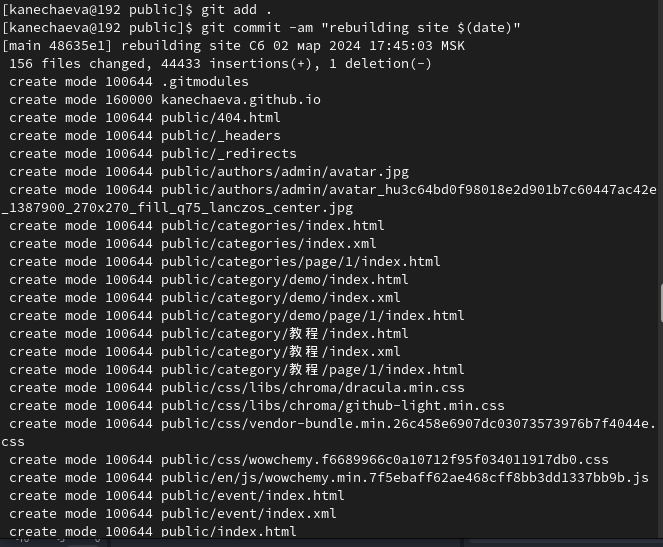

# Вывод

При выполнении данного этапа проекта я создала основныe элементы для сайта на hugo.

# Список литературы

## Код для формата `pdf`

```yaml
slide_level: 2
aspectratio: 169
section-titles: true
theme: metropolis
```

## Код для формата `html`

```
REVEALJS_THEME = beige
```